# Project: No-show appointments

- Introduction
- Data Wrangling
- Exploratory Data Analysis
- Conclusions

## Introduction

### Dataset Description

A person makes a doctor appointment, receives all the instructions and doesn't show up. which data can we relate it to?

### Question(s) for Analysis

We're gonna be looking into each question and explore other things that might show up along the way, and dismiss some of the possibilities

```python
import pandas as pd
import numpy as np
import matplotlib.pyplot as plt
import seaborn as sns
% matplotlib inline
```

```python
# Upgrade pandas to use dataframe.explode() function.
#!pip install --upgrade pandas==0.25.0
```

## Data Wrangling

Let's see what we should do with the data first

### General Properties

```python
df=pd.read_csv('noshow.csv')
df.head()
```

|  | PatientId | AppointmentID | Gender | ScheduledDay | AppointmentDay | Age | Neighbourhood | Scholarship | Hipertension | Diabetes | Alcoholism | Handcap | SMS_received | No-show |
| --- | --- | --- | --- | --- | --- | --- | --- | --- | --- | --- | --- | --- | --- | --- |
| 0 | 2.987250e+13 | 5642903 | F | 2016-04-29T18:38:08Z | 2016-04-29T00:00:00Z | 62 | JARDIM DA PENHA | 0 | 1 | 0 | 0 | 0 | 0 | No |
| 1 | 5.589978e+14 | 5642503 | M | 2016-04-29T16:08:27Z | 2016-04-29T00:00:00Z | 56 | JARDIM DA PENHA | 0 | 0 | 0 | 0 | 0 | 0 | No |
| 2 | 4.262962e+12 | 5642549 | F | 2016-04-29T16:19:04Z | 2016-04-29T00:00:00Z | 62 | MATA DA PRAIA | 0 | 0 | 0 | 0 | 0 | 0 | No |
| 3 | 8.679512e+11 | 5642828 | F | 2016-04-29T17:29:31Z | 2016-04-29T00:00:00Z | 8 | PONTAL DE CAMBURI | 0 | 0 | 0 | 0 | 0 | 0 | No |
| 4 | 8.841186e+12 | 5642494 | F | 2016-04-29T16:07:23Z | 2016-04-29T00:00:00Z | 56 | JARDIM DA PENHA | 0 | 1 | 1 | 0 | 0 | 0 | No |

let's start with some summary statistics

```python
df.shape
```

```
(110527, 14)
```

```python
df.dtypes
```

```
PatientId         float64
AppointmentID       int64
Gender             object
ScheduledDay       object
AppointmentDay     object
Age                 int64
Neighbourhood      object
Scholarship         int64
Hipertension        int64
Diabetes            int64
Alcoholism          int64
Handcap             int64
SMS_received        int64
No-show            object
dtype: object
```

```python
df.describe()
```

|  | PatientId | AppointmentID | Age | Scholarship | Hipertension | Diabetes | Alcoholism | Handcap | SMS_received |
| --- | --- | --- | --- | --- | --- | --- | --- | --- | --- |
| count | 1.105270e+05 | 1.105270e+05 | 110527.000000 | 110527.000000 | 110527.000000 | 110527.000000 | 110527.000000 | 110527.000000 | 110527.000000 |
| mean | 1.474963e+14 | 5.675305e+06 | 37.088874 | 0.098266 | 0.197246 | 0.071865 | 0.030400 | 0.022248 | 0.321026 |
| std | 2.560949e+14 | 7.129575e+04 | 23.110205 | 0.297675 | 0.397921 | 0.258265 | 0.171686 | 0.161543 | 0.466873 |
| min | 3.921784e+04 | 5.030230e+06 | -1.000000 | 0.000000 | 0.000000 | 0.000000 | 0.000000 | 0.000000 | 0.000000 |
| 25% | 4.172614e+12 | 5.640286e+06 | 18.000000 | 0.000000 | 0.000000 | 0.000000 | 0.000000 | 0.000000 | 0.000000 |
| 50% | 3.173184e+13 | 5.680573e+06 | 37.000000 | 0.000000 | 0.000000 | 0.000000 | 0.000000 | 0.000000 | 0.000000 |
| 75% | 9.439172e+13 | 5.725524e+06 | 55.000000 | 0.000000 | 0.000000 | 0.000000 | 0.000000 | 0.000000 | 1.000000 |
| max | 9.999816e+14 | 5.790484e+06 | 115.000000 | 1.000000 | 1.000000 | 1.000000 | 1.000000 | 4.000000 | 1.000000 |

minimum age is -1.0000 and that means that there is incorrect data to be cleaned Also, most of the patients don't have the scholarship or any disease, approximatly up to 75% of them so for starters i am gonna conclude most of these features won't be of any help but i still won't remove them for now

```python
df['No-show'].describe()
```

```
count     110527
unique         2
top           No
freq       88208
Name: No-show, dtype: object
```

we might need to change the columns type that are either 0 or 1 from float to string or the no show from string to an int or float

let's look at the date columns

```python
df.ScheduledDay.head()
```

```
0    2016-04-29T18:38:08Z
1    2016-04-29T16:08:27Z
2    2016-04-29T16:19:04Z
3    2016-04-29T17:29:31Z
4    2016-04-29T16:07:23Z
Name: ScheduledDay, dtype: object
```

```python
df.AppointmentDay.head()
```

```
0    2016-04-29T00:00:00Z
1    2016-04-29T00:00:00Z
2    2016-04-29T00:00:00Z
3    2016-04-29T00:00:00Z
4    2016-04-29T00:00:00Z
Name: AppointmentDay, dtype: object
```

defintely needs some cleaning

I didn't know what the handcap column actually refers to so let's take a look

```python
df.Handcap.unique()
```

```
array([0, 1, 2, 3, 4])
```

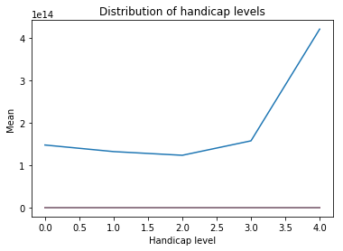

```python
x=df.groupby(['Handcap']).mean()
plt.title('Distribution of handicap levels')
plt.xlabel('Handicap level')
plt.ylabel('Mean')
plt.plot(x);
```

```python
df['Handcap'].value_counts(normalize=True) *100
```

```
0    97.972441
1     1.847512
2     0.165570
3     0.011762
4     0.002714
Name: Handcap, dtype: float64
```

```python
x=df.query('Handcap > 0')
y=df.query('Handcap == 0')
x.shape[0],y.shape[0]
```

```
(2241, 108286)
```

found out in kaggkle that there are four values because it indicated the severity of the handicap and 0 is healthy but it appears like the percentage of handicapped people is very low compared to the non handicaped, this column may not be very detrimental to the conclusion

let's check if there are null values

```python
df.isnull().sum()
```

```
PatientId         0
AppointmentID     0
Gender            0
ScheduledDay      0
AppointmentDay    0
Age               0
Neighbourhood     0
Scholarship       0
Hipertension      0
Diabetes          0
Alcoholism        0
Handcap           0
SMS_received      0
No-show           0
dtype: int64
```

cool, we won't have to replace any data

Let's check duplicated values

```python
df.duplicated().sum()
```

```
0
```

Also not gonna bother with that

### Data Cleaning

Let's start with lowercasing all the column names

```python
df.columns= df.columns.str.strip().str.lower()
df.head(1)
```

|  | patientid | appointmentid | gender | scheduledday | appointmentday | age | neighbourhood | scholarship | hipertension | diabetes | alcoholism | handcap | sms_received | no-show |
| --- | --- | --- | --- | --- | --- | --- | --- | --- | --- | --- | --- | --- | --- | --- |
| 0 | 2.987250e+13 | 5642903 | F | 2016-04-29T18:38:08Z | 2016-04-29T00:00:00Z | 62 | JARDIM DA PENHA | 0 | 1 | 0 | 0 | 0 | 0 | No |

Since it's much easier to remove the hyphen and underscore from the sms and no show column i am just gonna do that and also fix some names

```python
df=df.rename(columns={'hipertension': 'hypertension', 'handcap': 'handicap','sms_received':'smsreceived','no-show':'noshow'})
df.head(0)
```

|  | patientid | appointmentid | gender | scheduledday | appointmentday | age | neighbourhood | scholarship | hypertension | diabetes | alcoholism | handicap | smsreceived | noshow |
| --- | --- | --- | --- | --- | --- | --- | --- | --- | --- | --- | --- | --- | --- | --- |

Then let's start with dropping columns we won't need (I hardly doubt we'll get anything useful out of the IDs)

```python
df.drop(['patientid', 'appointmentid'], axis=1, inplace=True)
```

let's check what's up with the -1 values of the age column

```python
df.query('age==-1')
```

|  | gender | scheduledday | appointmentday | age | neighbourhood | scholarship | hypertension | diabetes | alcoholism | handicap | smsreceived | noshow |
| --- | --- | --- | --- | --- | --- | --- | --- | --- | --- | --- | --- | --- |
| 99832 | F | 2016-06-06T08:58:13Z | 2016-06-06T00:00:00Z | -1 | ROMÃO | 0 | 0 | 0 | 0 | 0 | 0 | No |

Alright it seems like a mistake so we'll just delete that record but is their any ages of zero?

```python
df.drop([99832],axis=0,inplace=True)
df.query('age==-1')
```

|  | gender | scheduledday | appointmentday | age | neighbourhood | scholarship | hypertension | diabetes | alcoholism | handicap | smsreceived | noshow |
| --- | --- | --- | --- | --- | --- | --- | --- | --- | --- | --- | --- | --- |

```python
df.query('age==0').shape
```

```
(3539, 12)
```

That's a lot of records, I am gonna assume the -1 was a mistake, and the zero records are for infant babies, 3539 records can't be a mistake.

let's reshape the data types to a coherant theme

```python
df['scheduledday'] = pd.to_datetime(df['scheduledday']).dt.date.astype('datetime64[ns]')
df['appointmentday'] = pd.to_datetime(df['appointmentday']).dt.date.astype('datetime64[ns]')
```

```python
df['scholarship'] = df['scholarship'].astype('object')
df['hypertension'] = df['hypertension'].astype('object')
df['diabetes'] = df['diabetes'].astype('object')
df['alcoholism'] = df['alcoholism'].astype('object')
df['handicap'] = df['handicap'].astype('object')
df['smsreceived'] = df['smsreceived'].astype('object')
```

```python
df.info()
```

```
<class 'pandas.core.frame.DataFrame'>
Int64Index: 110526 entries, 0 to 110526
Data columns (total 12 columns):
gender            110526 non-null object
scheduledday      110526 non-null datetime64[ns]
appointmentday    110526 non-null datetime64[ns]
age               110526 non-null int64
neighbourhood     110526 non-null object
scholarship       110526 non-null object
hypertension      110526 non-null object
diabetes          110526 non-null object
alcoholism        110526 non-null object
handicap          110526 non-null object
smsreceived       110526 non-null object
noshow            110526 non-null object
dtypes: datetime64[ns](2), int64(1), object(9)
memory usage: 11.0+ MB
```

```python
#we're gonna make a function which we are going to use multiple times in this project
#this function takes a column name and groups it with it's show or no show counterpart
#then divides their sizes giving us the ratio
def showratio(columnname):
    x=df[df.noshow=='No'].groupby(['{}'.format(columnname)])
    y=df.groupby(['{}'.format(columnname)])
    return x.size()/y.size()


def noshowratio(columnname):
    x=df[df.noshow=='Yes'].groupby(['{}'.format(columnname)])
    y=df.groupby(['{}'.format(columnname)])
    return x.size()/y.size()
```

## Exploratory Data Analysis

```python
data=df.groupby('noshow').size().sum()
showedup=df.groupby('noshow').size()[0]/data
noshow=df.groupby('noshow').size()[1]/data
print('percentage of people who showed up: {}%'.format(showedup*100))
print("percentage of people who didn't show up: {}%".format(noshow*100))
```

```
percentage of people who showed up: 79.80656135208005%
percentage of people who didn't show up: 20.193438647919944%
```

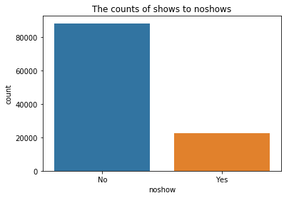

```python
ax = sns.countplot(x=df.noshow, data=df)
ax.set_title("The counts of shows to noshows")
plt.show()
```

Alright let's look at that and compare it with our data to start asking questions

Does gender matter?

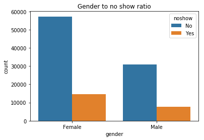

[output not shown]

```python
ax = sns.countplot(x=df.gender, hue=df.noshow, data=df)
x_ticks_labels=['Female', 'Male']
ax.set_xticklabels(x_ticks_labels)
ax.set_title("Gender to no show ratio")
plt.show()
mean=df.groupby('gender').mean()
sumg=df.groupby('gender').sum()
print (mean,'\n',sumg)
```

You might be able to tell that females book more appointments but also the ratio from shows to no shows still remains more or less the same as males gender might not play a big role in this ratio

Does age matter?

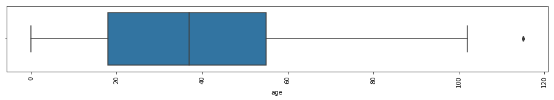

```python
plt.figure(figsize=(16,2))
plt.xticks(rotation=90)
_ = sns.boxplot(x=df.age)
```

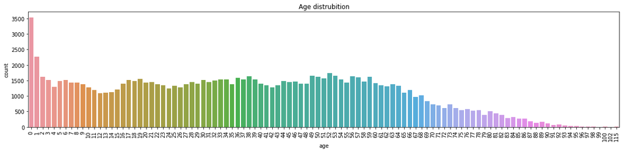

```python
plt.figure(figsize=(20,4))
plt.xticks(rotation=90)
ax = sns.countplot(x=df.age)
ax.set_title("Age distrubition")
plt.show()
```

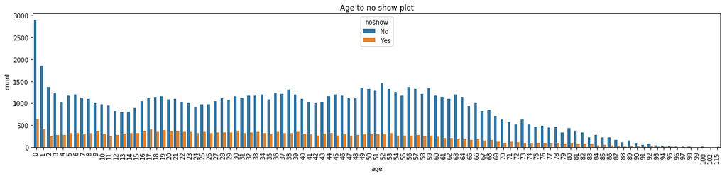

```python
plt.figure(figsize=(20,4))
plt.xticks(rotation=90)
ax = sns.countplot(x=df.age, hue=df.noshow)
ax.set_title("Age to no show plot")
plt.show()
```

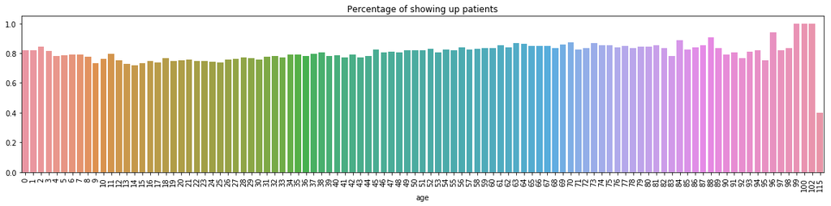

```python
df_age_ratio=showratio('age')
#df_age_ratio = df[df.noshow == 'No'].groupby(['age']).size()/df.groupby(['age']).size()
plt.figure(figsize=(20,4))
ax = sns.barplot(x=df_age_ratio.index, y=df_age_ratio)
plt.xticks(rotation=90)
ax.set_title("Percentage of showing up patients")
plt.show()
```

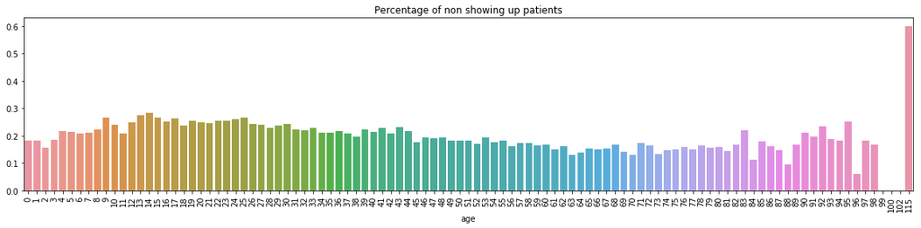

```python
df_age_ratio=noshowratio('age')
#df_age_ratio = df[df.noshow == 'Yes'].groupby(['age']).size()/df.groupby(['age']).size()
plt.figure(figsize=(20,4))
ax = sns.barplot(x=df_age_ratio.index, y=df_age_ratio)
plt.xticks(rotation=90)
ax.set_title("Percentage of non showing up patients")
plt.show()
```

The distribution of showing up across different ages seems to have no correlation with the reason, only at the 102 to 115 age does the ratio start to look weird but other than that it doesn't seem to have an effect

Let's look at the neighborhoods and how it affects our case

```python
df.neighbourhood.unique(), df.neighbourhood.unique().size
```

```
(array(['JARDIM DA PENHA', 'MATA DA PRAIA', 'PONTAL DE CAMBURI',
        'REPÚBLICA', 'GOIABEIRAS', 'ANDORINHAS', 'CONQUISTA',
        'NOVA PALESTINA', 'DA PENHA', 'TABUAZEIRO', 'BENTO FERREIRA',
        'SÃO PEDRO', 'SANTA MARTHA', 'SÃO CRISTÓVÃO', 'MARUÍPE',
        'GRANDE VITÓRIA', 'SÃO BENEDITO', 'ILHA DAS CAIEIRAS',
        'SANTO ANDRÉ', 'SOLON BORGES', 'BONFIM', 'JARDIM CAMBURI',
        'MARIA ORTIZ', 'JABOUR', 'ANTÔNIO HONÓRIO', 'RESISTÊNCIA',
        'ILHA DE SANTA MARIA', 'JUCUTUQUARA', 'MONTE BELO',
        'MÁRIO CYPRESTE', 'SANTO ANTÔNIO', 'BELA VISTA', 'PRAIA DO SUÁ',
        'SANTA HELENA', 'ITARARÉ', 'INHANGUETÁ', 'UNIVERSITÁRIO',
        'SÃO JOSÉ', 'REDENÇÃO', 'SANTA CLARA', 'CENTRO', 'PARQUE MOSCOSO',
        'DO MOSCOSO', 'SANTOS DUMONT', 'CARATOÍRA', 'ARIOVALDO FAVALESSA',
        'ILHA DO FRADE', 'GURIGICA', 'JOANA D´ARC', 'CONSOLAÇÃO',
        'PRAIA DO CANTO', 'BOA VISTA', 'MORADA DE CAMBURI', 'SANTA LUÍZA',
        'SANTA LÚCIA', 'BARRO VERMELHO', 'ESTRELINHA', 'FORTE SÃO JOÃO',
        'FONTE GRANDE', 'ENSEADA DO SUÁ', 'SANTOS REIS', 'PIEDADE',
        'JESUS DE NAZARETH', 'SANTA TEREZA', 'CRUZAMENTO',
        'ILHA DO PRÍNCIPE', 'ROMÃO', 'COMDUSA', 'SANTA CECÍLIA',
        'VILA RUBIM', 'DE LOURDES', 'DO QUADRO', 'DO CABRAL', 'HORTO',
        'SEGURANÇA DO LAR', 'ILHA DO BOI', 'FRADINHOS', 'NAZARETH',
        'AEROPORTO', 'ILHAS OCEÂNICAS DE TRINDADE', 'PARQUE INDUSTRIAL'], dtype=object),
 81)
```

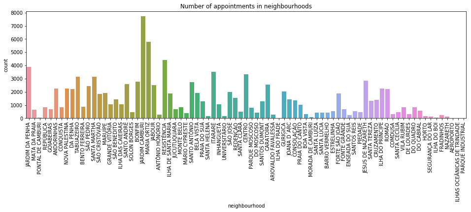

```python
plt.figure(figsize=(16,4))
ax = sns.countplot(df.neighbourhood)
plt.xticks(rotation=90)
plt.title('Number of appointments in neighbourhoods')
plt.show()
```

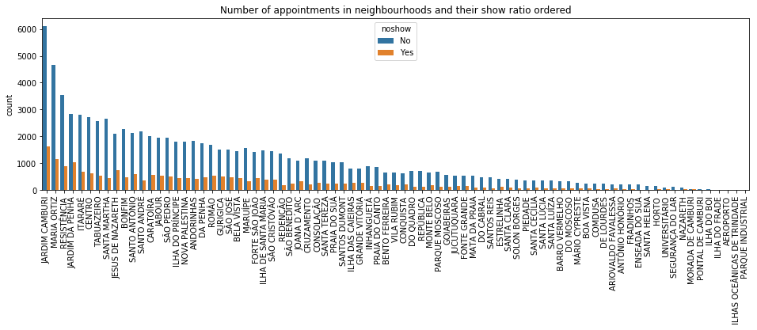

```python
plt.figure(figsize=(16,4))
ax = sns.countplot(np.sort(df.neighbourhood), hue=df.noshow, order=df.neighbourhood.value_counts().index)
plt.xticks(rotation=90)
plt.title('Number of appointments in neighbourhoods and their show ratio ordered')
plt.show()
```

We'll do what we did with the age and compare the ratios to get a better visual

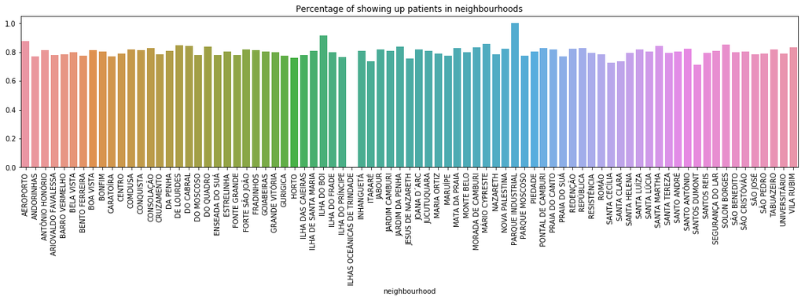

```python
df_n_ratio=showratio('neighbourhood')
#df_n_ratio = df[df.noshow == 'No'].groupby(['neighbourhood']).size()/df.groupby(['neighbourhood']).size()
plt.figure(figsize=(20,4))
plt.xticks(rotation=90)
ax = sns.barplot(x=df_n_ratio.index, y=df_n_ratio)
ax.set_title("Percentage of showing up patients in neighbourhoods")
plt.show()
```

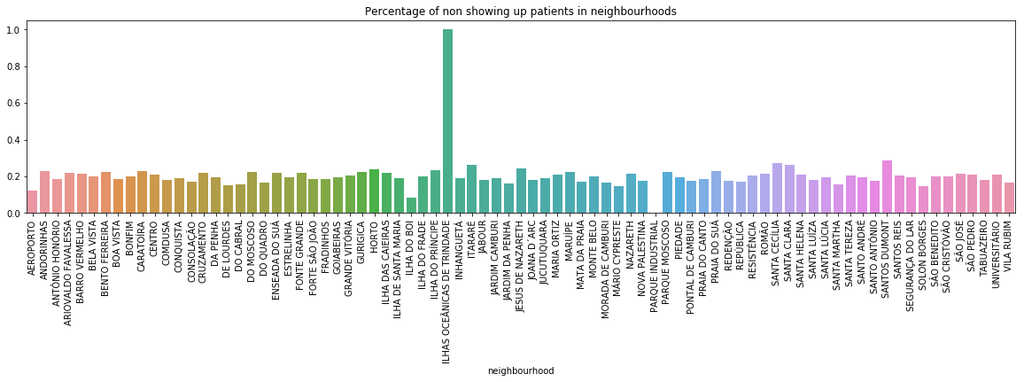

```python
df_n_ratio=noshowratio('neighbourhood')
#df_n_ratio = df[df.noshow == 'Yes'].groupby(['neighbourhood']).size()/df.groupby(['neighbourhood']).size()
plt.figure(figsize=(20,4))
plt.xticks(rotation=90)
ax = sns.barplot(x=df_n_ratio.index, y=df_n_ratio)
ax.set_title("Percentage of non showing up patients in neighbourhoods")
plt.show()
```

The sms recieved features seems important so let's see if it affects anything

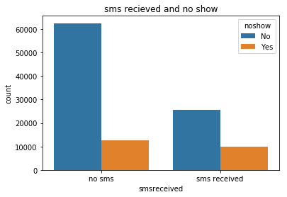

```python
ax=sns.countplot(x=df.smsreceived,hue=df.noshow)
plt.title('sms recieved and no show')
x_ticks_labels=['no sms', 'sms received']
ax.set_xticklabels(x_ticks_labels)
plt.show()
```

[figure not shown]

```python
df_n_ratio=showratio('smsreceived')
#df_s_ratio = df[df.noshow == 'No'].groupby(['smsreceived']).size()/df.groupby(['smsreceived']).size()
ax = sns.barplot(x=df_s_ratio.index, y=df_s_ratio, palette="RdBu_r")
ax.set_title("percentage for sms received")
x_ticks_labels=['no sms received', 'sms received']
ax.set_xticklabels(x_ticks_labels)
plt.show()
```

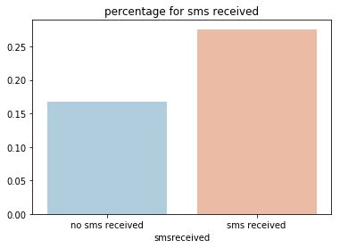

```python
df_n_ratio=noshowratio('smsreceived')
#df_s_ratio = df[df.noshow == 'Yes'].groupby(['smsreceived']).size()/df.groupby(['smsreceived']).size()
ax = sns.barplot(x=df_s_ratio.index, y=df_s_ratio, palette="RdBu_r")
ax.set_title("percentage for sms received")
x_ticks_labels=['no sms received', 'sms received']
ax.set_xticklabels(x_ticks_labels)
plt.show()
```

That's weird, patients who recieved the sms message showed up less, that's a weird correlation

We're gonna finish up our invistigation with the difference between when the appointment was scheduled and when it happened

This was supposed to happen during the cleaning phase but i left it till the end so let's create two new columns for the day of appointment and schedule days

```python
df['scday'] = df['scheduledday'].dt.weekday_name
df['appday'] = df['appointmentday'].dt.weekday_name
```

```python
df.tail()
```

|  | gender | scheduledday | appointmentday | age | neighbourhood | scholarship | hypertension | diabetes | alcoholism | handicap | smsreceived | noshow | scday | appday |
| --- | --- | --- | --- | --- | --- | --- | --- | --- | --- | --- | --- | --- | --- | --- |
| 110522 | F | 2016-05-03 | 2016-06-07 | 56 | MARIA ORTIZ | 0 | 0 | 0 | 0 | 0 | 1 | No | Tuesday | Tuesday |
| 110523 | F | 2016-05-03 | 2016-06-07 | 51 | MARIA ORTIZ | 0 | 0 | 0 | 0 | 0 | 1 | No | Tuesday | Tuesday |
| 110524 | F | 2016-04-27 | 2016-06-07 | 21 | MARIA ORTIZ | 0 | 0 | 0 | 0 | 0 | 1 | No | Wednesday | Tuesday |
| 110525 | F | 2016-04-27 | 2016-06-07 | 38 | MARIA ORTIZ | 0 | 0 | 0 | 0 | 0 | 1 | No | Wednesday | Tuesday |
| 110526 | F | 2016-04-27 | 2016-06-07 | 54 | MARIA ORTIZ | 0 | 0 | 0 | 0 | 0 | 1 | No | Wednesday | Tuesday |

I looked at the head and tail and the tail seemed to provide more info to how this data actually looks, let's create an additional waiting time column

```python
df['waitingtime'] = df['appointmentday'] - df['scheduledday']
df['waitingtime'] = df['waitingtime'].dt.days
df.tail()
```

|  | gender | scheduledday | appointmentday | age | neighbourhood | scholarship | hypertension | diabetes | alcoholism | handicap | smsreceived | noshow | scday | appday | waitingtime |
| --- | --- | --- | --- | --- | --- | --- | --- | --- | --- | --- | --- | --- | --- | --- | --- |
| 110522 | F | 2016-05-03 | 2016-06-07 | 56 | MARIA ORTIZ | 0 | 0 | 0 | 0 | 0 | 1 | No | Tuesday | Tuesday | 35 |
| 110523 | F | 2016-05-03 | 2016-06-07 | 51 | MARIA ORTIZ | 0 | 0 | 0 | 0 | 0 | 1 | No | Tuesday | Tuesday | 35 |
| 110524 | F | 2016-04-27 | 2016-06-07 | 21 | MARIA ORTIZ | 0 | 0 | 0 | 0 | 0 | 1 | No | Wednesday | Tuesday | 41 |
| 110525 | F | 2016-04-27 | 2016-06-07 | 38 | MARIA ORTIZ | 0 | 0 | 0 | 0 | 0 | 1 | No | Wednesday | Tuesday | 41 |
| 110526 | F | 2016-04-27 | 2016-06-07 | 54 | MARIA ORTIZ | 0 | 0 | 0 | 0 | 0 | 1 | No | Wednesday | Tuesday | 41 |

Now to get back to the visuals

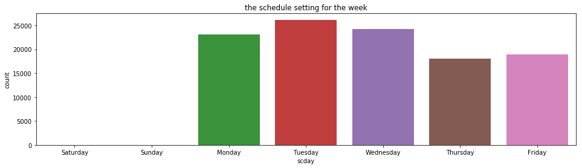

```python
week_key = ['Saturday','Sunday','Monday','Tuesday','Wednesday','Thursday','Friday']
plt.figure(figsize=(16,4))
ax = sns.countplot(x=df.scday, order=week_key)
ax.set_title("the schedule setting for the week")
plt.show()
```

Apperantly the people that take the calls for appointments don't work on saturdays or sundays

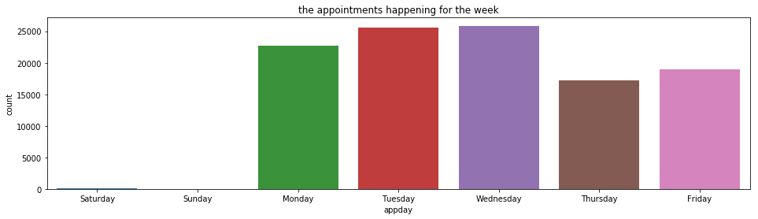

```python
week_key = ['Saturday','Sunday','Monday','Tuesday','Wednesday','Thursday','Friday']
plt.figure(figsize=(16,4))
ax = sns.countplot(x=df.appday, order=week_key)
ax.set_title("the appointments happening for the week")
plt.show()
```

So sundays might be off for the hospital but even though saturday isn't there still seems to be little to no appointments happening

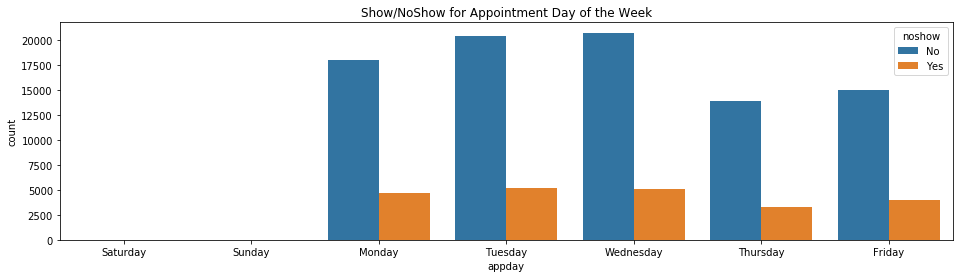

```python
plt.figure(figsize=(16,4))
ax = sns.countplot(x=df.appday, hue=df.noshow, order=week_key)
ax.set_title("Show/NoShow for Appointment Day of the Week")
plt.show()
```

[figure not shown]

```python
df_n_ratio=showratio('appday')
#df_app_ratio = df[df.noshow == 'No'].groupby(['appday']).size()/df.groupby(['appday']).size()
plt.figure(figsize=(16,4))
ax = sns.barplot(x=df_app_ratio.index, y=df_app_ratio, order=week_key)
ax.set_title("Show Percent for Appointment Day of the Week")
plt.show()
```

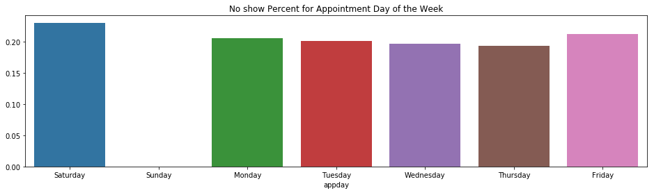

```python
df_n_ratio=noshowratio('appday')
#df_app_ratio = df[df.noshow == 'Yes'].groupby(['appday']).size()/df.groupby(['appday']).size()
plt.figure(figsize=(16,4))
ax = sns.barplot(x=df_app_ratio.index, y=df_app_ratio, order=week_key)
ax.set_title("No show Percent for Appointment Day of the Week")
plt.show()
```

There seems to be very little difference in the reasons for showing up in different days of the week themselves, but there seems to be something in the ratios of showing up that might be useful

Let's take a quick look at the waiting time column

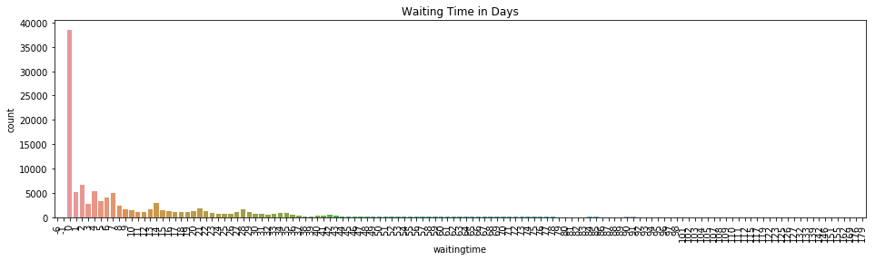

```python
plt.figure(figsize=(16,4))
ax = sns.countplot(x=df.waitingtime)
plt.xticks(rotation=90)
ax.set_title("Waiting Time in Days")
plt.show()
```

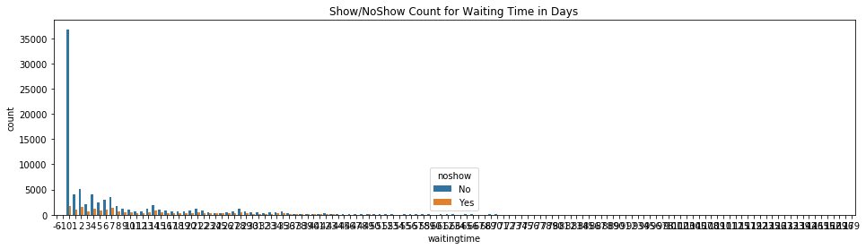

```python
plt.figure(figsize=(16,4))
ax = sns.countplot(x=df.waitingtime, hue=df.noshow)
ax.set_title("Show/NoShow Count for Waiting Time in Days")
plt.show()
```

## Conclusions

-it seems to me like the gap between appointment and schedule might be one of the deciding factors although the amount itself might not matter  
-for some strange reason people who recieve text messages of their appointment show up less?  
-the age and neighborhood might not affect the showing up rates that much

### Limitations

-The data seems to be in some manner or form not correctly collected resulting in very undecisive results  
-the features weren't very descriptive or very helpful

```python
from subprocess import call
call(['python', '-m', 'nbconvert', 'Investigate_a_Dataset.ipynb'])
```

```
0
```